# ASSIGNMENT 7 Exercise 12: Housing Data

## Question I:

**Use the appropriate function to show the sum of large residuals.**

### Answer for I

```r
sum(realestate_df$large.residual)
```

```
## [1] 284
```

## Question J:

**Which specific variables have large residuals (only cases that evaluate as TRUE)?**

### Answer for J

```r
realestate_df[realestate_df$large.residual, c("Sale Price", "building_grade", "square_feet_total_living", "bedrooms", "total_bath", "year_built", "sq_ft_lot", "standardized.residuals")]
```

```
## # A tibble: 284 x 8
##    `Sale Price` building_grade square_feet_tot… bedrooms total_bath year_built
##           <dbl>          <dbl>            <dbl>    <dbl>      <dbl>      <dbl>
##  1      1392000              9             3740        4       4.33       1998
##  2      1053649              9             2680        2       2.5        2005
##  3      1080135              9             2700        3       2.33       2006
##  4       732500              9             5710        5       4.33       1977
##  5       370000              9             4000        4       3.5        2014
##  6      1588359              9             3360        2       2.5        2005
##  7      1450000              8             3480        3       2.5        1972
##  8      1450000              6              900        2       1          1918
##  9      1369900             11             4630        5       2.67       2005
## 10      1174477              9             2800        3       2.5        2006
## # … with 274 more rows, and 2 more variables: sq_ft_lot <dbl>,
## #   standardized.residuals <dbl>
```

## Question K:

**Investigate further by calculating the leverage, cooks distance, and covariance rations. Comment on all cases that are problematic.**

### Answer for K

```r
realestate_df[realestate_df$large.residual, c("cooks.distance", "leverage", "covariance.ratios")]
```

```
## # A tibble: 284 x 3
##    cooks.distance leverage covariance.ratios
##             <dbl>    <dbl>             <dbl>
##  1       0.00717  0.00238              0.990
##  2       0.000993 0.000883             0.997
##  3       0.000478 0.000334             0.995
##  4       0.00926  0.00544              0.999
##  5       0.00266  0.000883             0.989
##  6       0.00990  0.00158              0.976
##  7       0.0103   0.00203              0.982
##  8       0.0514   0.00341              0.942
##  9       0.00173  0.00190              0.999
## 10       0.000710 0.000335             0.992
## # … with 274 more rows
```

> the above generated 284 rows but there is no row where cooks distance is greater than 1, so there are no problematic rows

## Question L:

**Perform the necessary calculations to assess the assumption of independence and state if the condition is met or not.**

### Answer for L

```r
library("car")
dwt(salepricebymultiplevar_lm)
```

```
##  lag Autocorrelation D-W Statistic p-value
##    1       0.4054537      1.189018       0
##  Alternative hypothesis: rho != 0
```

## Question M:

**Perform the necessary calculations to assess the assumption of no multicollinearity and state if the condition is met or not.**

### Answer for M

```r
## vif
vif(salepricebymultiplevar_lm)
```

```
## realestate_df$square_feet_total_living               realestate_df$year_built
##                               3.745030                               1.711507
##                 realestate_df$bedrooms               realestate_df$total_bath
##                               2.000033                               2.163369
##           realestate_df$building_grade
##                               1.943865
```

```r
## 1/vif
1/vif(salepricebymultiplevar_lm)
```

```
## realestate_df$square_feet_total_living               realestate_df$year_built
##                              0.2670206                              0.5842806
##                 realestate_df$bedrooms               realestate_df$total_bath
##                              0.4999917                              0.4622420
##           realestate_df$building_grade
##                              0.5144390
```

```r
## mean
mean(vif(salepricebymultiplevar_lm))
```

```
## [1] 2.312761
```

## Question N:

**Visually check the assumptions related to the residuals using the plot() and hist() functions. Summarize what each graph is informing you of and if any anomalies are present.**

### Answer for N

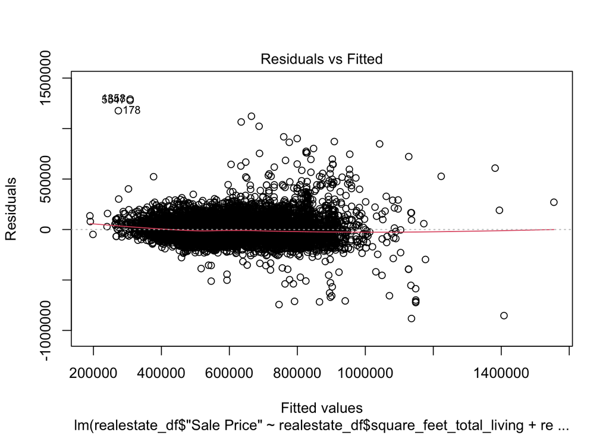

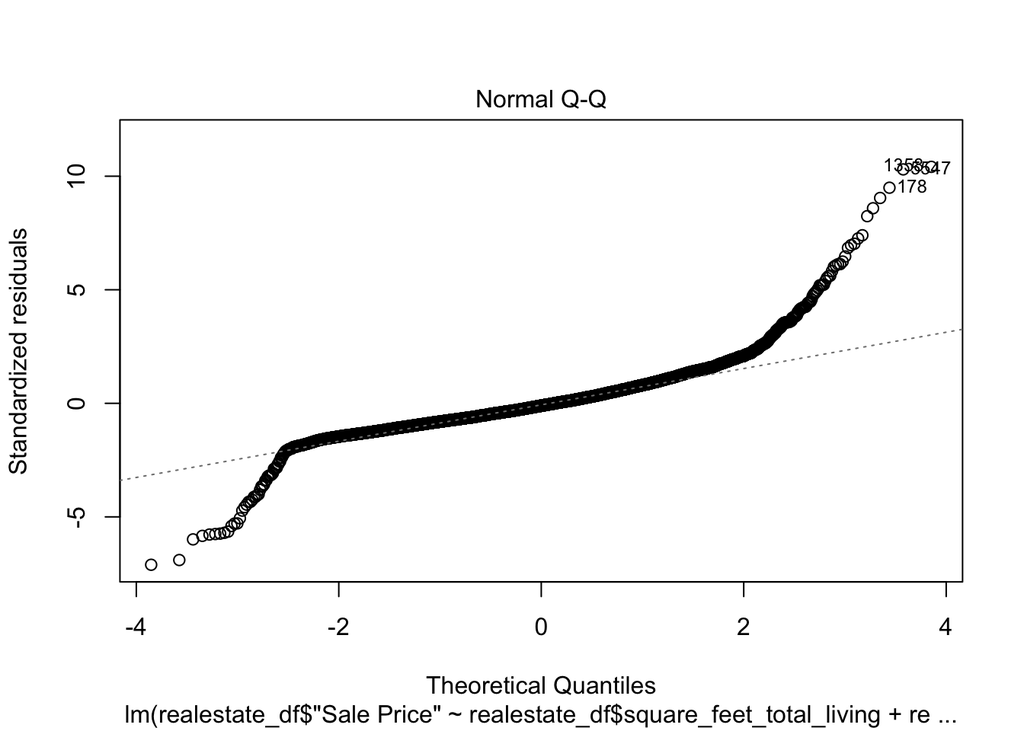

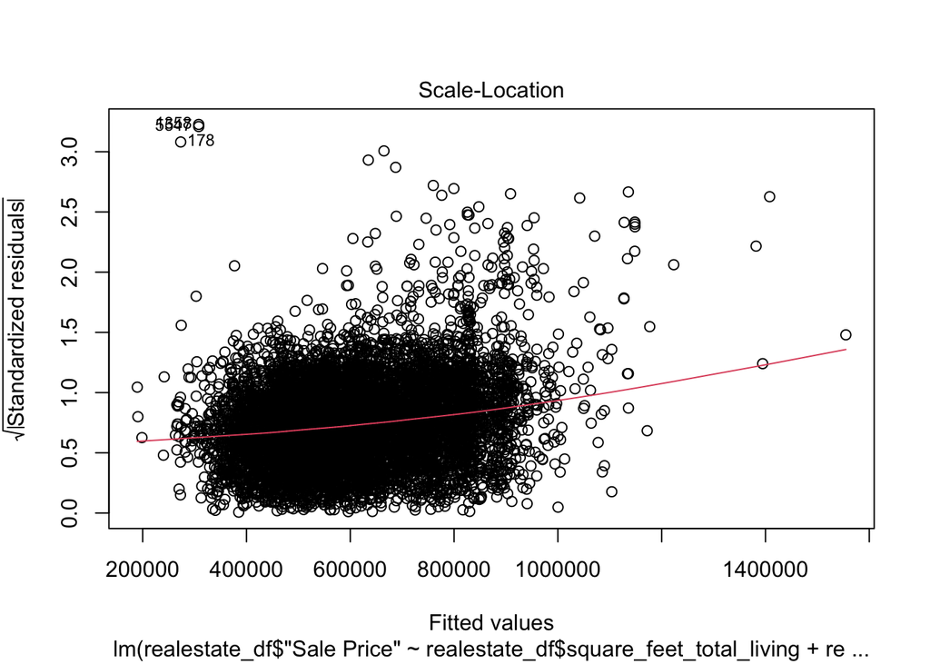

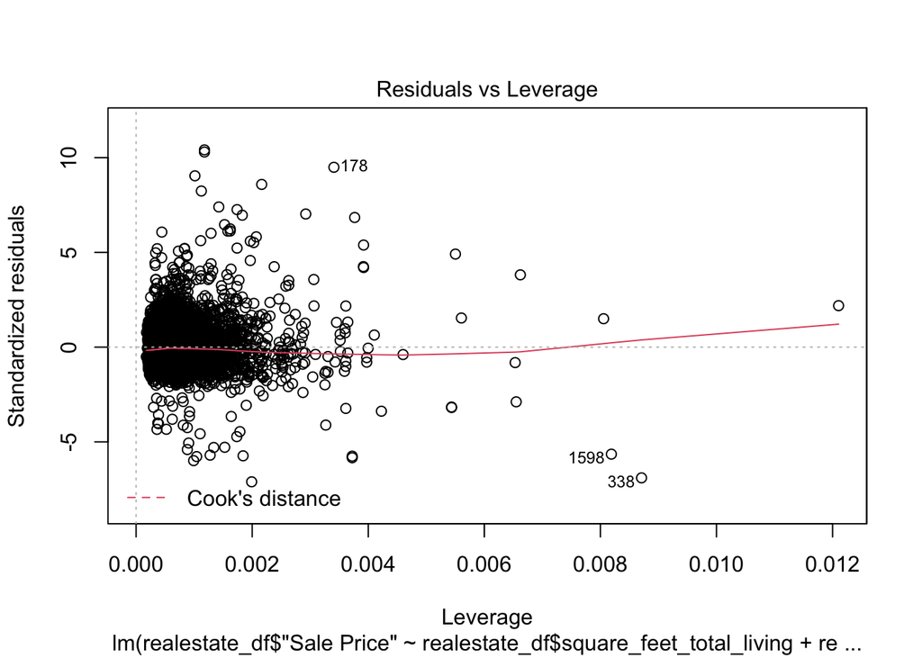

```r
library(ggplot2)
plot(salepricebymultiplevar_lm)
```

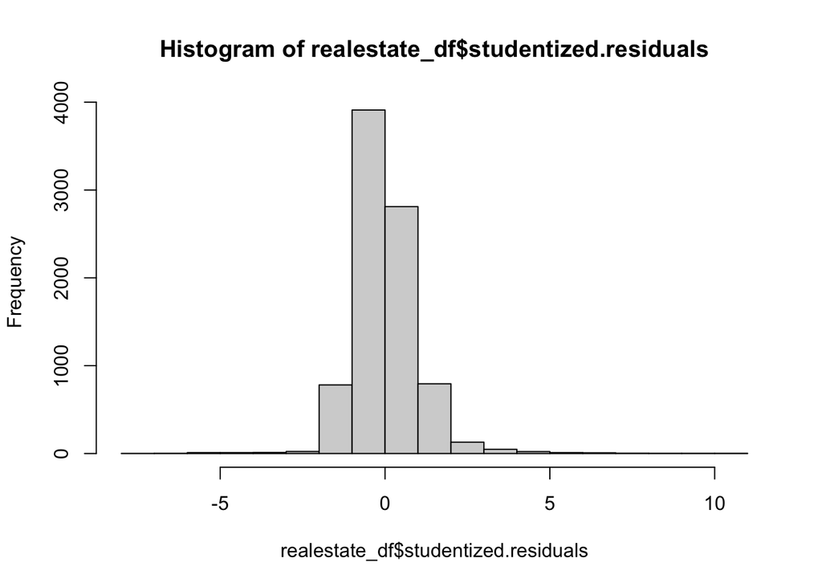

```r
hist(realestate_df$studentized.residuals)
```

```r
scatter <- ggplot(realestate_df, aes(fitted, studentized.residuals)) + geom_point() + geom_smooth(method = "lm", colour = "Blue")+ labs(x = "Fitted Values", y = "Studentized Residual")
```

> The Normal Q-Q plot should show deviations from normality. In the plot above, it deviates from both the ends of the line, which indicates deviation of normality at the extreme values.

## Question O:

**Overall, is this regression model unbiased? If an unbiased regression model, what does this tell us about the sample vs. the entire population model?**